# Trabajo Final Estadística 2

Emiliano Zepeda y Alonso Iberico

29/10/2021

Emiliano Zepeda (20192020) Alonso Iberico (20183122)

Grupo: Los lobos esteparios

#Trabajo Final-Trabajo Grupal Estadística para el análisis político 2

#Tema: Apoyo a la democracia en Venezuela y Uruguay en el año 2020: Variables y explicaciones.

#Pregunta de investigación: ¿Cuál es la situación de la democracia en Uruguay y Venezuela en el 2020?

Bibliografía: Brewer, A. (2009). La demolición del Estado de Derecho y la Destrucción de la Democracia en Venezuela (1999-2009). Ciudad de México: Universidad Nacional Autónoma de México.

Chacín, R. (2019). El nuevo autoritarismo latinoamericano: Un reto para la democracia y los derechos humanos (análisis del caso venezolano). Estudios Constitucionales, 17 (1), pp. 15-52. Consulta: 29 de octubre de 2021 en: https://www.scielo.cl/scielo.php?script=sci_arttext&pid=S0718-52002019000100015&lang=pt

Lissidini, A. (2020). Uruguay: sin déficit democrático y con giro electoral. REVISTA EUROLATINOAMERICANA DE ANÁLISIS SOCIAL Y POLÍTICO, 1(1), 187-198. http://www.ojs.unsj.edu.ar/index.php/relasp/article/view/513

Méndez Leiva, G. (2020). Las elecciones primarias presidenciales en Chile, Argentina y Uruguay, ¿un incentivo a la participación electoral? (Doctoral dissertation, Universidad del Desarrollo. Facultad de Gobierno). http://repositorio.udd.cl/handle/11447/3452

Romero, C., & Benayas, G. (2019). Venezuela: el ocaso de una democracia. Revista Mexicana de Ciencias Políticas y Sociales, 233, pp. 285-306. Consulta: 28 de octubre de 2021 en: http://www.scielo.org.mx/scielo.php?script=sci_arttext&pid=S0185-19182018000200285

Santos, Y., & Martínez, O. (2017). La insatisfacción con la democracia en América Latina. Análisis de factores económicos y políticos en 2017. Revista de Ciencias Sociales y Humanas, 32, pp.157-174. Consulta: 27 de octubre del 2021 en: https://www.redalyc.org/journal/4761/476162468008/html/

Vargas, D., & González, J. (2013). Los determinantes de la satisfacción con la democracia, desde el enfoque de un modelo multinivel. Econoquantum, 10(2). doi: 2007-9869. http://www.scielo.org.mx/scielo.php?script=sci_arttext&pid=S1870-66222013000200003

Wike, R., Silver, L., & Castillo, A. (2019). Many People Around the World Are Unhappy With How Democracy Is Working. Consulta: 28 de Octubre del 2021 en https://www.pewresearch.org/global/2019/04/29/many-across-the-globe-are-dissatisfied-with-how-democracy-is-working/

#METODOLOGÍA: El enfoque elegido fue el de no experimental, ya que consideramos a la base de datos del Latino barómetro de 2020, como la mejor para poder responder a la pregunta de investigación y de este modo aproximarnos a los casos de Uruguay y Venezuela, tomando en cuenta a las variables dependientes como el apoyo a la democracia y la satisfacción con la democracia, mientras nuestras variables independientes vendrían a ser el Índice de confianza en el Estado, la imagen del progreso del país, satisfacción con el funcionamiento de la economía. En este sentido, el proceso de recolección se dio en una muestra de 20204 personas de varios países de Latinoamérica para tener cierto grado de representación respecto a la población total de la región, teniendo como tipo de muestreo el probabilístico puesto que fue un muestreo aleatorio para de esta manera conseguir un alto margen de posibilidades de respuesta; después, el instrumento de aplicación fue un cuestionario, en el cual se le pregunto a los participantes desde preguntas que incluye niveles de menos a más entre sí hasta dicotómicas. Por lo tanto, los instrumentos de recolección realizados por el Latino barómetro se centraron en las respuestas obtenidas de los participantes respecto a las preguntas realizadas en el cuestionario tales como las siguientes: En su opinión, ¿Cuál considera Ud. que es el problema más importante en el país?,¿Considera Ud. que la situación económica actual del país está mucho mejor, un poco mejor, igual, un poco peor, o mucho peor que hace doce meses? , En política se habla normalmente de “izquierda” y “derecha”. En una escala dónde “00” es la “izquierda” y “10” la “derecha”, ¿Dónde se ubicaría Ud.?,etc. Por último, las técnicas estadísticas utilizadas en este trabajo se dieron en este orden: En primer lugar, se decidió crear dos indicadores, uno que contenga las variables de la confianza en el Estado como son la policía o el gobierno y otro que contenga las variables de la confianza en organismo no gubernamentales como son las ONG o Sindicatos; en segundo lugar, se hizo una descripción de la medidas de tendencia central y de dispersión tanto de las variables dependientes como independientes; en tercer lugar, se paso a realizar un análisis factorial con las variables independientes para reducir aun más los valores de los mismos para obtener la cantidad de factores óptimos; por último, se realizó una regresión lineal múltiple con los factores obtenidos con las variables dependientes para poder determinar un resultado a la pregunta de investigación y ver cuanto logra explicar este modelo.

#HALLAZGOS:

En el presente trabajo se realizará un análisis de componentes de las variables independientes y luego un modelo de regresión lineal de estos componentes con las variables independientes en cada país.

#Identificación del país en la base de datos:

Uruguay=858 Venezuela=862

Apoyo a la democracia=P10stgbs

```r
library(rio)
library(DescTools)
library(psych)
library(dplyr)
library(tidyr)
data=import("Latinobarometro_2020_Esp_Rdata_v1_0.rdata")
subset_general=subset(data,data$idenpa==858|data$idenpa==862)
subset_venezuela=subset(data,data$idenpa==862)
subset_uruguay=subset(data,data$idenpa==858)
```

#Variables Independientes:

Para realizar este estudio, se eligieron las siguientes variables independientes: P2ST Imagen del progreso del país

P11STGBS.B Satisfacción con el funcionamiento de la economía en (país)

Desde P13S.D hasta P13S.I: Índice de Confianza en el Estado.

P17STGBS Aprobación de la gestion del gobierno que encabeza el presidente (nombre)

#Dependientes: A su vez, se eligieron las siguientes variables dependientes:

P10STGBS Apoyo a la democracia

P11STGBS.A Satisfacción con la democracia

#Análisis Decriptivo de las variables independientes: P2ST Imagen del progreso del país:

```r
#En Venezuela
summary(subset_venezuela$p2st)
```

```
##    Min. 1st Qu.  Median    Mean 3rd Qu.    Max.
##  -2.000   2.000   3.000   2.386   3.000   3.000
```

```r
describeBy(subset_venezuela$p2st)
```

```
##    vars    n mean   sd median trimmed mad min max range  skew kurtosis   se
## X1    1 1200 2.39 0.81      3    2.52   0  -2   3     5 -2.04     6.32 0.02
```

```r
Mode(subset_venezuela$p2st)
```

```
## [1] 3
## attr(,"freq")
## [1] 624
```

```r
#En Uruguay:
summary(subset_uruguay$p2st)
```

```
##    Min. 1st Qu.  Median    Mean 3rd Qu.    Max.
##   -2.00    1.00    2.00    1.82    2.00    3.00
```

```r
describeBy(subset_uruguay$p2st)
```

```
##    vars    n mean   sd median trimmed  mad min max range  skew kurtosis   se
## X1    1 1200 1.82 0.85      2    1.84 1.48  -2   3     5 -0.94     2.55 0.02
```

```r
Mode(subset_uruguay$p2st)
```

```
## [1] 2
## attr(,"freq")
## [1] 586
```

P11STGBS.B Satisfacción con el funcionamiento de la economía en (país)

```r
#En Venezuela:
summary(subset_venezuela$P11STGBS.B)
```

```
##    Min. 1st Qu.  Median    Mean 3rd Qu.    Max.
##  -2.000   3.000   4.000   3.632   4.000   4.000
```

```r
describeBy(subset_venezuela$P11STGBS.B)
```

```
##    vars    n mean   sd median trimmed mad min max range  skew kurtosis   se
## X1    1 1200 3.63 0.78      4    3.79   0  -2   4     6 -3.33    15.02 0.02
```

```r
Mode(subset_venezuela$P11STGBS.B)
```

```
## [1] 4
## attr(,"freq")
## [1] 880
```

La variable satisfacción con el funcionamiento de la economía en Venezuela tiene como mediana el valor 4, de media 3.62 y moda 4 con una frecuencia de 880.Por lo tanto, los venezolanos en promedio se encuentran nada satisfecho con la economía ya que media al encontrarse más cerca al valor 4 se ha considerado esta interpretación, teniendo en cuenta que en el libro de códigos, 1=Muy satisfecho y 4=nada satisfechos. En este sentido, la varianza al obtener de valor 1 nos dice que la variabilidad de los datos respecto a la media es sensible al ser la media de un valor de 3.632 y la desviación estándar al conseguir 0.78 nos señala que los valores de la media se encuentran bastante dispersas entre sí al dividirse en 5 partes respecto al promedio.

```r
#En Uruguay:
summary(subset_uruguay$P11STGBS.B)
```

```
##    Min. 1st Qu.  Median    Mean 3rd Qu.    Max.
##  -2.000   2.000   3.000   2.594   3.000   4.000
```

```r
describeBy(subset_uruguay$P11STGBS.B)
```

```
##    vars    n mean   sd median trimmed  mad min max range  skew kurtosis   se
## X1    1 1200 2.59 1.18      3    2.75 1.48  -2   4     6 -1.88     4.91 0.03
```

```r
Mode(subset_uruguay$P11STGBS.B)
```

```
## [1] 3
## attr(,"freq")
## [1] 566
```

Creamos el Índice de Confianza en el Estado con las variables desde P13ST.D hasta P13ST.I

```r
#En general:
subset_general$indice_conf_pais=(subset_general$p13st.d+subset_general$p13st.e+subset_general$p13st.f+subset_general$p13st.g+subset_general$p13st.h+subset_general$p13st.i)/6
summary(subset_general$indice_conf_pais)
```

```
##    Min. 1st Qu.  Median    Mean 3rd Qu.    Max.
##  -2.000   2.000   2.833   2.738   3.667   4.000
```

```r
describeBy(subset_general$indice_conf_pais)
```

```
##    vars    n mean   sd median trimmed  mad min max range  skew kurtosis   se
## X1    1 2400 2.74 1.02   2.83    2.82 1.24  -2   4     6 -0.71     0.67 0.02
```

```r
Mode(subset_general$indice_conf_pais)
```

```
## [1] 4
## attr(,"freq")
## [1] 407
```

```r
#En Venezuela
subset_venezuela$indice_conf_pais=(subset_venezuela$p13st.d+subset_venezuela$p13st.e+subset_venezuela$p13st.f+subset_venezuela$p13st.g+subset_venezuela$p13st.h+subset_venezuela$p13st.i)/6
summary(subset_venezuela$indice_conf_pais)
```

```
##    Min. 1st Qu.  Median    Mean 3rd Qu.    Max.
##  -2.000   2.667   3.500   3.186   4.000   4.000
```

```r
describeBy(subset_venezuela$indice_conf_pais)
```

```
##    vars    n mean   sd median trimmed  mad min max range skew kurtosis   se
## X1    1 1200 3.19 0.92    3.5    3.33 0.74  -2   4     6 -1.4     2.58 0.03
```

```r
Mode(subset_venezuela$indice_conf_pais)
```

```
## [1] 4
## attr(,"freq")
## [1] 354
```

El Índice de Confianza en el Estado en Venezuela tiene como mediana el valor 3.5, de media 3.186 y moda 4 con una frecuencia de 354.Por lo tanto, los venezolanos en promedio encuentran poca confianza en las instituciones del Estado ya que la media al encontrarse más cerca al valor 3 se ha considerado esta interpretación, considerando que en el libro de códigos se indica, con relación a la confianza en las instituciones del Estado que esta oscila entre 1 y 4, donde: 1=Mucha y 4=Ninguna. En este sentido, la varianza al obtener de valor 1 nos dice que la variabilidad de los datos respecto a la media es sensible al ser la media de un valor de 3.186 y la desviación estándar al conseguir 0.92 nos señala que los valores de la media se encuentran bastante dispersas entre sí al dividirse en 4 partes respecto al promedio.

```r
#En Uruguay:
subset_uruguay$indice_conf_pais=(subset_uruguay$p13st.d+subset_uruguay$p13st.e+subset_uruguay$p13st.f+subset_uruguay$p13st.g+subset_uruguay$p13st.h+subset_uruguay$p13st.i)/6
summary(subset_uruguay$indice_conf_pais)
```

```
##    Min. 1st Qu.  Median    Mean 3rd Qu.    Max.
##  -2.000   1.667   2.333   2.290   3.000   4.000
```

```r
describeBy(subset_uruguay$indice_conf_pais)
```

```
##    vars    n mean   sd median trimmed  mad min max range  skew kurtosis   se
## X1    1 1200 2.29 0.92   2.33    2.31 0.99  -2   4     6 -0.54     1.37 0.03
```

```r
Mode(subset_uruguay$indice_conf_pais)
```

```
## [1] 2
## attr(,"freq")
## [1] 121
```

El Índice de Confianza en el Estado en Uruguay tiene como mediana el valor 2.33, de media 2.29 y moda 2 con una frecuencia de 121.Por lo tanto, los uruguayos en promedio se encuentran algo confiados en las instituciones del Estado ya que la media al encontrarse más cerca al valor 2 se ha considerado esta interpretación, considerando lo mencionado con anterioridad con relación a la estructura de esta variable. En este sentido, la varianza al obtener de valor 1 nos dice que la variabilidad de los datos respecto a la media es sensible al ser la media de un valor de 2.29 y la desviación estándar al conseguir 0.92 nos señala que los valores de la media se encuentran muy poco dispersas entre sí al dividirse en 2 partes respecto al promedio.

Creamos el Índice de Confianza en insituciones no gubernamentales con las variables desde P15ST.A hasta P15ST.G.

```r
#En general:
subset_general$indice_conf_inst_ng=(subset_general$p15st.a+subset_general$p15st.b+subset_general$p15st.c+subset_general$p15st.d+subset_general$p15st.e+subset_general$p15st.f+subset_general$p15st.g)/7
summary(subset_general$indice_conf_inst_ng)
```

```
##    Min. 1st Qu.  Median    Mean 3rd Qu.    Max.
##  -2.000   2.000   2.429   2.427   3.000   4.000
```

```r
describeBy(subset_general$indice_conf_inst_ng)
```

```
##    vars    n mean   sd median trimmed  mad min max range  skew kurtosis   se
## X1    1 2400 2.43 0.93   2.43    2.49 0.85  -2   4     6 -0.85     1.53 0.02
```

```r
Mode(subset_general$indice_conf_inst_ng)
```

```
## [1] 2.428571
## attr(,"freq")
## [1] 194
```

```r
#En Venezuela:
subset_venezuela$indice_conf_inst_ng=(subset_venezuela$p15st.a+subset_venezuela$p15st.b+subset_venezuela$p15st.c+subset_venezuela$p15st.d+subset_venezuela$p15st.e+subset_venezuela$p15st.f+subset_venezuela$p15st.g)/7
summary(subset_venezuela$indice_conf_inst_ng)
```

```
##    Min. 1st Qu.  Median    Mean 3rd Qu.    Max.
##  -1.571   2.286   2.857   2.744   3.286   4.000
```

```r
describeBy(subset_venezuela$indice_conf_inst_ng)
```

```
##    vars    n mean   sd median trimmed  mad   min max range  skew kurtosis   se
## X1    1 1200 2.74 0.85   2.86     2.8 0.85 -1.57   4  5.57 -0.82     1.23 0.02
```

```r
Mode(subset_venezuela$indice_conf_inst_ng)
```

```
## [1] 3
## attr(,"freq")
## [1] 101
```

```r
#En Uruguay:
subset_uruguay$indice_conf_inst_ng=(subset_uruguay$p15st.a+subset_uruguay$p15st.b+subset_uruguay$p15st.c+subset_uruguay$p15st.d+subset_uruguay$p15st.e+subset_uruguay$p15st.f+subset_uruguay$p15st.g)/7
summary(subset_uruguay$indice_conf_inst_ng)
```

```
##    Min. 1st Qu.  Median    Mean 3rd Qu.    Max.
##  -2.000   1.714   2.214   2.110   2.714   4.000
```

```r
describeBy(subset_uruguay$indice_conf_inst_ng)
```

```
##    vars    n mean   sd median trimmed  mad min max range  skew kurtosis   se
## X1    1 1200 2.11 0.91   2.21    2.19 0.74  -2   4     6 -1.03        2 0.03
```

```r
Mode(subset_uruguay$indice_conf_inst_ng)
```

```
## [1] 2.428571
## attr(,"freq")
## [1] 108
```

La variable Índice de confianza en instituciones no gubernamentales en Uruguay tiene como mediana el valor de 2.21 , de media 2.11 y moda es 2.43 y su frecuencia es de 108 .Por lo tanto, los uruguayos en promedio sí tienen una confianza relativamente alta en las instituciones no gubernamentales, puesto que el libro de códigos indica que esta variable oscila entre 1 y 4, donde 1=Mucha y 4=Ninguna, por lo que la valoracion 2 implica ello. En este sentido, la varianza al obtener de valor 1 nos dice que la variabilidad de los datos respecto a la media es sensible al ser de 1, y la desviación estandar al conseguir 0.91 nos señala que los valores de la media se encuentra muy poco dispersos entre si al dividirse en 4 partes respecto al promedio.

P17STGBS Aprobación de la gestion del gobierno que encabeza el presidente (nombre):

```r
#En Venezuela
summary(subset_venezuela$p17stgbs)
```

```
##    Min. 1st Qu.  Median    Mean 3rd Qu.    Max.
##  -2.000   1.000   2.000   1.454   2.000   2.000
```

```r
describeBy(subset_venezuela$p17stgbs)
```

```
##    vars    n mean   sd median trimmed mad min max range  skew kurtosis   se
## X1    1 1200 1.45 1.03      2     1.7   0  -2   2     4 -2.47     5.58 0.03
```

```r
Mode(subset_venezuela$p17stgbs)
```

```
## [1] 2
## attr(,"freq")
## [1] 791
```

La variable Aprobación de la gestión del gobierno que encabeza el presidente Maduro en Venezuela tiene como mediana el valor de 2 , de media 1.45 y moda es 2,con una frecuencia de 791 .Por lo tanto, los venezolanos en promedio no aprueba la gestión del presidente Maduro, puesto que el libro de códigos indica que esta variable oscila tiene 2 respuestas: 1 y 2, donde 1=Sí aprueba y 2=No aprueba, por lo que la valoracion 2 implica ello. En este sentido, la varianza al obtener de valor 1 nos dice que la variabilidad de los datos respecto a la media es sensible al ser de 1, y la desviación estandar al conseguir 1.03 nos señala que los valores de la media se encuentra muy poco dispersos entre si al dividirse en 2 partes respecto al promedio, hecho que indica poca variabilidad entre las respuestas.

```r
#En Uruguay
summary(subset_uruguay$p17stgbs)
```

```
##    Min. 1st Qu.  Median    Mean 3rd Qu.    Max.
##  -2.000   1.000   1.000   1.093   2.000   2.000
```

```r
describeBy(subset_uruguay$p17stgbs)
```

```
##    vars    n mean   sd median trimmed mad min max range  skew kurtosis   se
## X1    1 1200 1.09 1.04      1     1.3   0  -2   2     4 -1.96     3.73 0.03
```

```r
Mode(subset_uruguay$p17stgbs)
```

```
## [1] 1
## attr(,"freq")
## [1] 692
```

#Análisis descriptivo de las variables dependientes: P10STGBS Apoyo a la democracia

```r
#En Venezuela:
summary(subset_venezuela$p10stgbs)
```

```
##    Min. 1st Qu.  Median    Mean 3rd Qu.    Max.
##  -2.000   1.000   1.000   1.258   1.000   3.000
```

```r
describeBy(subset_venezuela$p10stgbs)
```

```
##    vars    n mean   sd median trimmed mad min max range skew kurtosis   se
## X1    1 1200 1.26 0.96      1    1.24   0  -2   3     5 0.02     1.25 0.03
```

```r
Mode(subset_venezuela$p10stgbs)
```

```
## [1] 1
## attr(,"freq")
## [1] 854
```

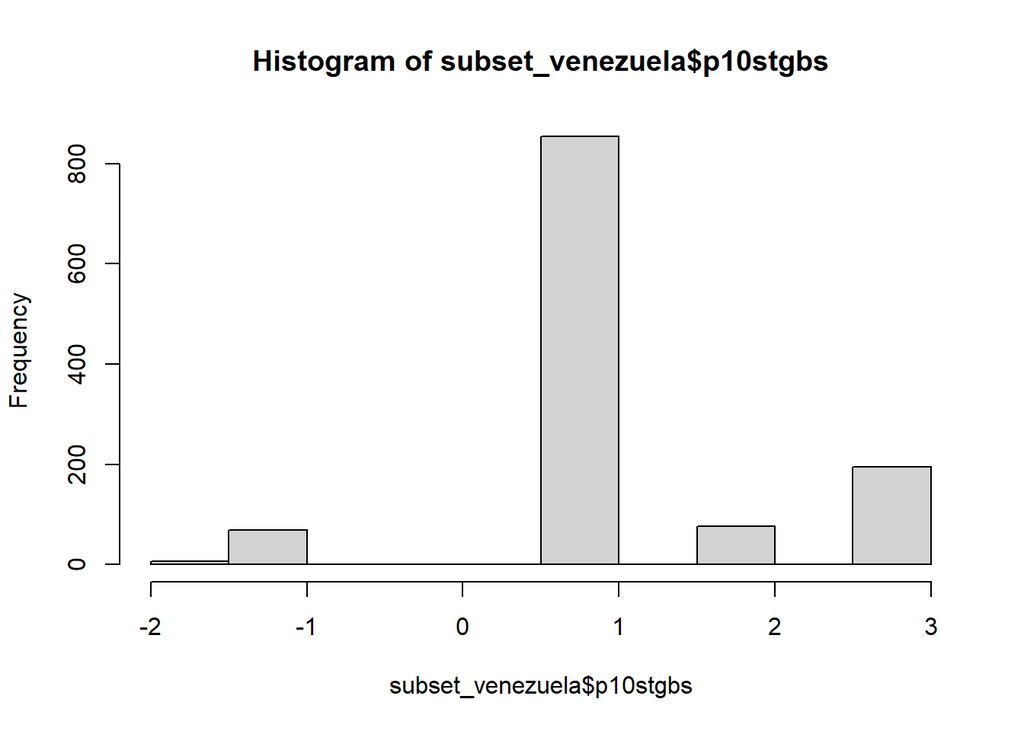

```r
hist(subset_venezuela$p10stgbs)
```

La variable Apoyo a la democracia en Venezuela tiene como mediana el valor de 1 , de media 1.258 y su moda es 1,con una frecuencia de 854.Por lo tanto, los venezolanos en promedio sí apoyan la democracia, puesto que el libro de códigos indica que esta variable oscila entre 1 y 3 donde 1=La democracia es preferible a cualquier otra forma de gobierno; 2=En algunas circunstancias, un gobierno autoritario puede ser preferible; y 3=A la gente como uno, nos da lo mismo un régimen democrático que uno no democrático, por lo que la valoracion 1 implica un apoyo hacia los regímenes democráticos. En este sentido, la varianza al obtener de valor 1 nos dice que la variabilidad de los datos respecto a la media es sensible al ser de 1, y la desviación estandar al conseguir 0.96 también nos señala que los valores de la media se encuentra muy poco dispersos entre si al dividirse en 3 partes respecto al promedio, hecho que indica poca variabilidad entre las respuestas.

```r
#En Uruguay:
summary(subset_uruguay$p10stgbs)
```

```
##    Min. 1st Qu.  Median    Mean 3rd Qu.    Max.
##  -2.000   1.000   1.000   1.198   1.000   3.000
```

```r
describeBy(subset_uruguay$p10stgbs)
```

```
##    vars    n mean   sd median trimmed mad min max range  skew kurtosis   se
## X1    1 1200  1.2 0.92      1    1.16   0  -2   3     5 -0.21     2.45 0.03
```

```r
Mode(subset_uruguay$p10stgbs)
```

```
## [1] 1
## attr(,"freq")
## [1] 888
```

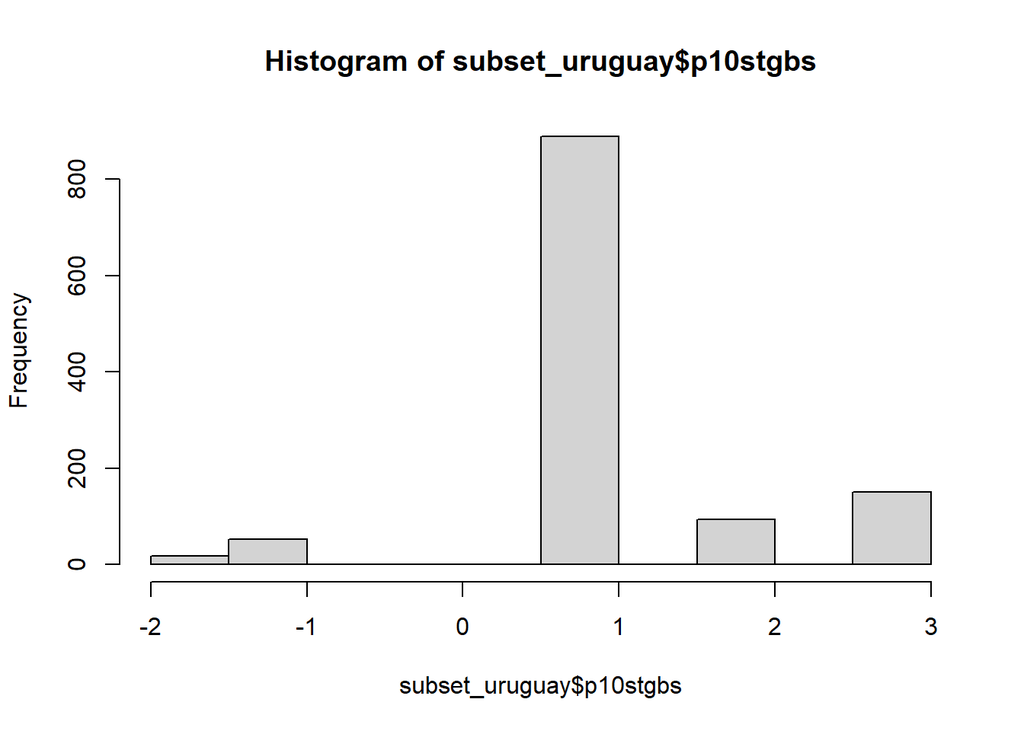

```r
hist(subset_uruguay$p10stgbs)
```

La variable Apoyo a la democracia en Uruguay tiene como mediana el valor de 1 , de media 1.198 y su moda es 1,con una frecuencia de 888.Por lo tanto, los uruguayos en promedio también apoyan la democracia, puesto que el libro de códigos indica que esta variable oscila entre 1 y 3 donde 1=La democracia es preferible a cualquier otra forma de gobierno; 2=En algunas circunstancias, un gobierno autoritario puede ser preferible; y 3=A la gente como uno, nos da lo mismo un régimen democrático que uno no democrático, por lo que la valoracion 1 implica un apoyo hacia los regímenes democráticos en Uruguay. En este sentido, la varianza al obtener de valor 1 nos dice que la variabilidad de los datos respecto a la media es sensible al ser de 1, y la desviación estandar al conseguir 0.92 también nos señala que los valores de la media se encuentra muy poco dispersos entre si al dividirse en 3 partes respecto al promedio, hecho que indica poca variabilidad entre las respuestas.

P11STGBS.A Satisfacción con la democracia:

```r
#En Venezuela:
summary(subset_venezuela$P11STGBS.A)
```

```
##    Min. 1st Qu.  Median    Mean 3rd Qu.    Max.
##  -2.000   3.000   4.000   3.258   4.000   4.000
```

```r
describeBy(subset_venezuela$P11STGBS.A)
```

```
##    vars    n mean   sd median trimmed mad min max range  skew kurtosis   se
## X1    1 1200 3.26 1.07      4    3.47   0  -2   4     6 -1.84     3.96 0.03
```

```r
Mode(subset_uruguay$P11STGBS.A)
```

```
## [1] 2
## attr(,"freq")
## [1] 542
```

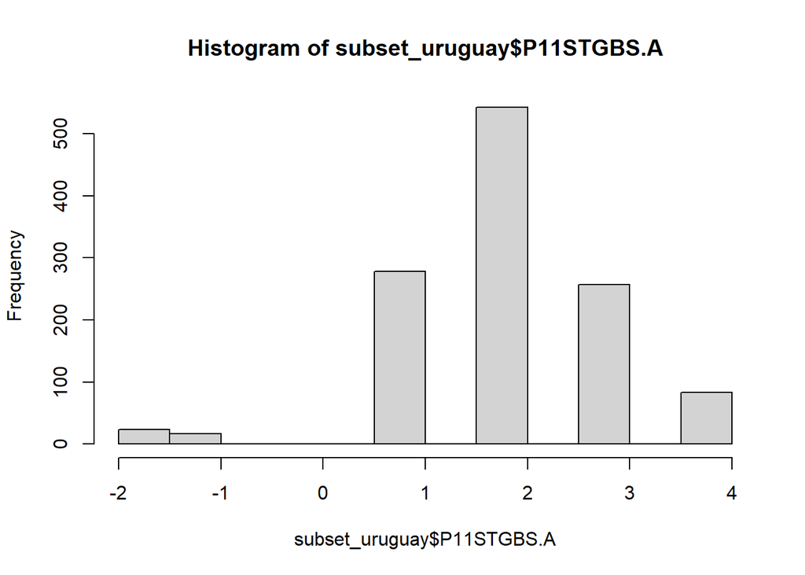

```r
hist(subset_uruguay$P11STGBS.A)
```

```r
#En Uruguay:
summary(subset_uruguay$P11STGBS.A)
```

```
##    Min. 1st Qu.  Median    Mean 3rd Qu.    Max.
##  -2.000   1.000   2.000   2.002   3.000   4.000
```

```r
describeBy(subset_uruguay$P11STGBS.A)
```

```
##    vars    n mean   sd median trimmed  mad min max range  skew kurtosis   se
## X1    1 1200    2 1.08      2    2.02 1.48  -2   4     6 -0.87     2.68 0.03
```

```r
Mode(subset_uruguay$P11STGBS.A)
```

```
## [1] 2
## attr(,"freq")
## [1] 542
```

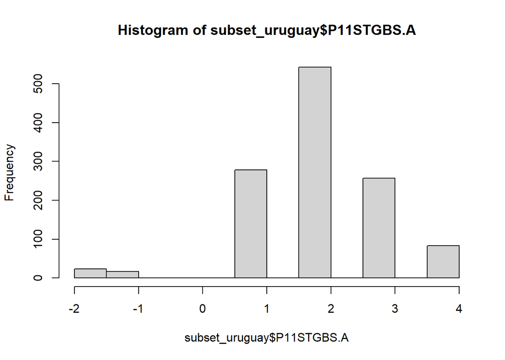

```r
hist(subset_uruguay$P11STGBS.A)
```

La variable Satisfacción con la democracia en Uruguay tiene como mediana el valor de 2 , de media 2.002 y su moda también es 2,con una frecuencia de 542. Por lo tanto, los uruguayos en promedio están medianamente satisfechos con la democracia, tal como se evidencia en su apoyo hacia la misma, puesto que el libro de códigos indica que esta variable oscila entre 1 y 4 donde 1=Muy satisfecho y 4=Nada Satisfecho, por lo que el promedio de 2.002 implica una satisfacción moderada con los regímenes democráticos en Uruguay. A su vez, la varianza al obtener de valor 1 nos dice que la variabilidad de los datos respecto a la media es sensible al ser de 1, y la desviación estandar al conseguir 1.08 también nos señala que los valores de la media se encuentra muy poco dispersos entre si al dividirse en 4 partes respecto a la media, hecho que indica poca variabilidad entre las respuestas.

#Modelos de regresión a ser utilizados:

```r
str(subset_venezuela$p2st)
```

```
##  int [1:1200] 2 2 1 2 2 3 2 1 3 3 ...
```

```r
str(subset_uruguay$p2st)
```

```
##  int [1:1200] 3 3 2 2 2 1 2 1 2 1 ...
```

```r
str(subset_venezuela$P11STGBS.B)
```

```
##  int [1:1200] 4 4 3 4 3 4 4 3 4 4 ...
```

```r
str(subset_uruguay$P11STGBS.B)
```

```
##  int [1:1200] 3 4 2 4 4 3 4 2 2 3 ...
```

```r
str(subset_venezuela$indice_conf_pais)
```

```
##  num [1:1200] 2.33 2.83 1.5 2 1.83 ...
```

```r
str(subset_uruguay$indice_conf_pais)
```

```
##  num [1:1200] 2.67 2.5 1.33 2.67 2.67 ...
```

```r
str(subset_venezuela$indice_conf_inst_ng)
```

```
##  num [1:1200] 1.71 3.14 1.86 2 2.57 ...
```

```r
str(subset_uruguay$indice_conf_inst_ng)
```

```
##  num [1:1200] 2.43 1.57 2 3.43 3.14 ...
```

```r
str(subset_venezuela$p10stgbs)
```

```
##  int [1:1200] 3 1 1 -1 1 1 1 2 1 3 ...
```

```r
str(subset_uruguay$p10stgbs)
```

```
##  int [1:1200] 1 1 2 3 2 1 2 1 1 1 ...
```

```r
str(subset_venezuela$P11STGBS.A)
```

```
##  int [1:1200] 1 3 1 4 3 4 4 2 4 4 ...
```

```r
str(subset_uruguay$P11STGBS.A)
```

```
##  int [1:1200] 1 2 3 -2 4 2 3 2 4 1 ...
```

```r
str(subset_venezuela$p17stgbs)
```

```
##  int [1:1200] 2 1 1 1 1 2 2 2 2 2 ...
```

```r
str(subset_uruguay$p17stgbs)
```

```
##  int [1:1200] 2 2 1 -2 1 2 1 -2 2 1 ...
```

Hacemos un subset con las variables independientes en Venezuela y Uruguay:

```r
names(subset_venezuela)
```

```
##   [1] "numinves"            "idenpa"              "numentre"
##   [4] "reg"                 "ciudad"              "tamciud"
##   [7] "comdist"             "edad"                "sexo"
##  [10] "codigo"              "diareal"             "mesreal"
##  [13] "ini"                 "fin"                 "dura"
##  [16] "totrevi"             "totcuot"             "totrech"
##  [19] "totperd"             "numcasa"             "codsuper"
##  [22] "supervvi"            "superven"            "codif"
##  [25] "digit"               "p1st"                "p2st"
##  [28] "p3stgbs"             "p4stgbs"             "p5stgbs"
##  [31] "p6st"                "p7stgbs"             "p8st.a"
##  [34] "p8st.b"              "p8st.c"              "p9stgbs"
##  [37] "p10stgbs"            "P11STGBS.A"          "P11STGBS.B"
##  [40] "p12st"               "P13STGBS.A"          "P13STGBS.B"
##  [43] "p13st.c"             "p13st.d"             "p13st.e"
```

[output cut: 122 more lines]

```r
subset_venezuela_ind=subset_venezuela[,c(27,39,94,409,410)]
names(subset_venezuela_ind)
```

```
## [1] "p2st"                "P11STGBS.B"          "p17stgbs"
## [4] "indice_conf_pais"    "indice_conf_inst_ng"
```

```r
str(subset_venezuela_ind)
```

```
## 'data.frame':    1200 obs. of  5 variables:
##  $ p2st               : int  2 2 1 2 2 3 2 1 3 3 ...
##  $ P11STGBS.B         : int  4 4 3 4 3 4 4 3 4 4 ...
##  $ p17stgbs           : int  2 1 1 1 1 2 2 2 2 2 ...
##  $ indice_conf_pais   : num  2.33 2.83 1.5 2 1.83 ...
##  $ indice_conf_inst_ng: num  1.71 3.14 1.86 2 2.57 ...
```

```r
library(foreign)
library(nnet)
library(ggplot2)
library(reshape2)
library(car)
#Dada la estructura de algunas variables, vamos a recodificarlas para que vayan de menor a mayor. Ejm: En p2st, antes: 1=el país está progresando, 2= está estancado, 3= está en retroceso. Ahora será 1=está en retroceso, 2=está estancada y 3=está progresando.
table(subset_venezuela_ind$p2st)
```

```
##
##  -2  -1   1   2   3
##   4  23  76 473 624
```

```r
subset_venezuela_ind$p2st=recode(subset_venezuela_ind$p2st,"1=3;3=1")
subset_venezuela_ind$p2st[subset_venezuela_ind$p2st=="-2"]=NA
subset_venezuela_ind$p2st[subset_venezuela_ind$p2st=="-1"]=NA
table(subset_venezuela_ind$P11STGBS.B)
```

```
##
##  -2  -1   1   2   3   4
##   2  10  19  34 255 880
```

```r
subset_venezuela_ind$P11STGBS.B[subset_venezuela_ind$P11STGBS.B=="-1"]=NA
subset_venezuela_ind$P11STGBS.B[subset_venezuela_ind$P11STGBS.B=="-2"]=NA
table(subset_venezuela_ind$P11STGBS.B)
```

```
##
##   1   2   3   4
##  19  34 255 880
```

```r
subset_venezuela_ind$P11STGBS.B=recode(subset_venezuela_ind$P11STGBS.B,"1=4;2=3;3=2;4=1")
subset_venezuela_ind$p17stgbs=recode(subset_venezuela_ind$p17stgbs,"1=2;2=1")
subset_venezuela_ind$p17stgbs[subset_venezuela_ind$p17stgbs=="-2"]=NA
table(subset_venezuela_ind$p17stgbs)
```

```
##
##   1   2
## 791 327
```

#Para Venezuela: Primero realizamos la matriz de correlaciones entre las variables independientes.

```r
library(polycor)
library(psych)
corMatrix=polycor::hetcor(subset_venezuela_ind)$correlations
corMatrix
```

```
##                           p2st P11STGBS.B   p17stgbs indice_conf_pais
## p2st                 1.0000000  0.3677432  0.4689359       -0.4940078
## P11STGBS.B           0.3677432  1.0000000  0.4184307       -0.4799338
## p17stgbs             0.4689359  0.4184307  1.0000000       -0.7117811
## indice_conf_pais    -0.4940078 -0.4799338 -0.7117811        1.0000000
## indice_conf_inst_ng -0.1828449 -0.2408884 -0.2595503        0.4361260
##                     indice_conf_inst_ng
## p2st                         -0.1828449
## P11STGBS.B                   -0.2408884
## p17stgbs                     -0.2595503
## indice_conf_pais              0.4361260
## indice_conf_inst_ng           1.0000000
```

Observamos que en el caso venezolano existen tanto correlaciones positivas como negativas, así como también positivas y negativas. Por ejemplo, la variable “Índice de confianza en las instituciones del país” tiene una correlación negativa fuerte con la variable “aprobación de la gestión del gobierno que encabeza el presidente”. De manera análoga, la variable “Índice de confianza en las instituciones no gubernamentales” tiene una correlación moderada con la variable “Confianza en las instituciones del país”. Ahora lo vemos de manera gráfica:

[figure not shown]

```r
library(corrplot)
correlacion=round(cor(subset_venezuela_ind),1)
corrplot(correlacion,method="number",type="upper")
```

Observamos, en primera instancia, una correlación moderada entre los índices de confianza en las instituciones del país y las no gubernamentales.

De manera preliminar, a partir de lo observado en la matriz de correlaciones, se puede afirmar que sí se puede realizar un buen análisis factorial, al identificar ciertos grupos entre variables, las cuales evidencian un buen nivel de asociación. Sin embargo, esto se verificará a continuación. Primero verificamos el valor del KMO:

```r
KMO(corMatrix)
```

```
## Kaiser-Meyer-Olkin factor adequacy
## Call: KMO(r = corMatrix)
## Overall MSA =  0.75
## MSA for each item =
##                p2st          P11STGBS.B            p17stgbs    indice_conf_pais
##                0.87                0.88                0.72                0.69
## indice_conf_inst_ng
##                0.73
```

Para determinar si existen correlaciones entre las variables se solicita un valor de por lo menos 0.5 en el Overall MSA. En este caso nuestro Overall MSA es de 0.75, por lo que se nos dan luces de que sí podemos realizar un buen análisis factorial.

Ahora verificamos si la matriz de correlaciones es adecuada mediante el Test de Barlett.

- Test de Barlett: H0: La matriz de correlación es una matriz de identidad. Buscamos rechazar la H0, por eso esperamos que sea significativo (False)

```r
cortest.bartlett(corMatrix,n=nrow(subset_venezuela_ind))$p.value>0.05
```

```
## [1] FALSE
```

Dado este resultado, rechazamos la hipótesis nula de que la presente matriz de correlación es una matriz de identidad. De esta manera, concluimos que las variables sí se relacionan con las demás, por lo que sí se puede realizar un análisis factorial.

Para determiunar el número adecuado de componentes, vamos a observar el gráfico de sedimentación.

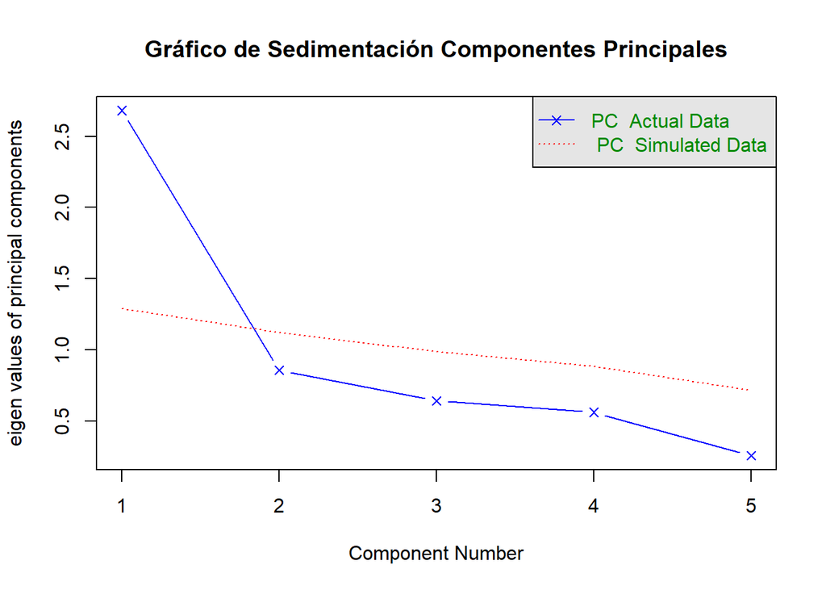

```
## Parallel analysis suggests that the number of factors =  NA  and the number of components =  1
```

```r
fa.parallel(corMatrix,fm="pa",fa="pc",main="Gráfico de Sedimentación Componentes Principales")
```

El Gráfico de Sedimentación de Componentes Principales indica que, entre las variables independientes, solo hay 1 componente principal. Para verificarlo realizaremos el análisis de los autovalores para poder identificar la cantidad de varianza explicada por los componentes o variables latentes.

```r
library(factoextra)
```

```r
library(FactoMineR)
res.pca=PCA(subset_venezuela_ind, graph = FALSE)
eig.val=get_eig(res.pca)
eig.val
```

```
##       eigenvalue variance.percent cumulative.variance.percent
## Dim.1  2.5965682        51.931365                    51.93136
## Dim.2  0.8810967        17.621934                    69.55330
## Dim.3  0.6576051        13.152102                    82.70540
## Dim.4  0.5656772        11.313543                    94.01894
## Dim.5  0.2990528         5.981056                   100.00000
```

Ciertamente, solo hay 1 componente principal entre las variables independientes. De esta manera, no es preciso otorgarle un nombre específico a este. No obstante, cuánto explica cada variable se verá a continuación.

```r
comp=pca(subset_venezuela_ind,nfactors=1,rotate = "varimax")
print(comp$loadings)
```

```
##
## Loadings:
##                     PC1
## p2st                 0.673
## P11STGBS.B           0.674
## p17stgbs             0.822
## indice_conf_pais    -0.882
## indice_conf_inst_ng -0.557
##
##                  PC1
## SS loadings    2.671
## Proportion Var 0.534
```

Ahora normalizamos las escalas:

```r
library(BBmisc)
comp_casos=as.data.frame(comp$scores)
head(comp_casos)
```

```
##              PC1
## 19005  0.4205407
## 19006  0.5651504
## 19007  2.1842478
## 19008  1.1458844
## 19009  1.4792278
## 19010 -1.1502406
```

```r
subset_venezuela_ind$comp_1=comp_casos$PC1
subset_venezuela_ind$comp_1_normalizado=normalize(subset_venezuela_ind$comp_1,
                                        method = "range",
                                        margin=2, # by column
                                        range = c(0, 100))
```

La agregamos al subset original y hacemos el modelo. #Modelo de regresión lineal con la satisfacción con la democracia: Primero recordamos que la variable satisfacción con la democracia tiene la siguiente estructura: 1=Muy satisfecho 2=Más bien satisfecho 3=No muy satisfecho 4=Nada satisfecho La vamos a recodificar para que sea de menor satisfacción a mayor satisfacción, al igual que en las variables dependientes, para que sigan la misma lógica.

```r
str(subset_venezuela$P11STGBS.A)
```

```
##  int [1:1200] 1 3 1 4 3 4 4 2 4 4 ...
```

```r
subset_venezuela$P11STGBS.A=as.numeric(subset_venezuela$P11STGBS.A)
subset_venezuela$P11STGBS.A[subset_venezuela$P11STGBS.A=="-1"]=NA
subset_venezuela$P11STGBS.A[subset_venezuela$P11STGBS.A=="-2"]=NA
table(subset_venezuela$P11STGBS.A)
```

```
##
##   1   2   3   4
##  70 124 319 665
```

```r
subset_venezuela$P11STGBS.A=recode(subset_venezuela$P11STGBS.A,"1=4;2=3;3=2;4=1")
table(subset_venezuela$P11STGBS.A)
```

```
##
##   1   2   3   4
## 665 319 124  70
```

```r
subset_venezuela$independientes=subset_venezuela_ind$comp_1_normalizado
modelo_venezuela=lm(subset_venezuela$P11STGBS.A~subset_venezuela$independientes)
summary(modelo_venezuela)
```

```
##
## Call:
## lm(formula = subset_venezuela$P11STGBS.A ~ subset_venezuela$independientes)
##
## Residuals:
##     Min      1Q  Median      3Q     Max
## -2.1419 -0.3545 -0.1315  0.3211  3.0420
##
## Coefficients:
##                                  Estimate Std. Error t value Pr(>|t|)
## (Intercept)                     0.9579618  0.0299338   32.00   <2e-16 ***
## subset_venezuela$independientes 0.0290811  0.0009496   30.63   <2e-16 ***
## ---
## Signif. codes:  0 '***' 0.001 '**' 0.01 '*' 0.05 '.' 0.1 ' ' 1
##
## Residual standard error: 0.65 on 1075 degrees of freedom
##   (123 observations deleted due to missingness)
## Multiple R-squared:  0.466,  Adjusted R-squared:  0.4655
## F-statistic: 937.9 on 1 and 1075 DF,  p-value: < 2.2e-16
```

```r
#Coeficientes
modelo_venezuela$coefficients
```

```
##                     (Intercept) subset_venezuela$independientes
##                      0.95796184                      0.02908114
```

A partir de los coeficientes, planteamos la ecuación: Satisfacción con la democracia en Venezuela=0.95796184 + 0.02908114(Variables independientes sobre confianza y percepción de la democracia)

#Modelo con variable Apoyo a la Democracia en Venezuela:

Al igual que con la variable de satisfacción con la democracia, es preciso destacar que la variable Apoyo a la Democracia tiene la siguiente estructura: 1=La democracia es preferible 2=Un gobierno autoritario puede ser preferible en algunas circunstancias 3=A la gente le da igual el régimen.

Entonces, es preciso recodificarla de la siguiente manera: 1=Un gobierno autoritario puede ser preferible 2=Le da igual 3= La democracia es preferible

```r
str(subset_venezuela$p10stgbs)
```

```
##  int [1:1200] 3 1 1 -1 1 1 1 2 1 3 ...
```

```r
subset_venezuela$p10stgbs=as.numeric(subset_venezuela$p10stgbs)
subset_venezuela$p10stgbs[subset_venezuela$p10stgbs=="-1"]=NA
subset_venezuela$p10stgbs[subset_venezuela$p10stgbs=="-2"]=NA
table(subset_venezuela$p10stgbs)
```

```
##
##   1   2   3
## 854  76 195
```

```r
subset_venezuela$p10stgbs=recode(subset_venezuela$p10stgbs,"1=3;2=1;3=2")
table(subset_venezuela$p10stgbs)
```

```
##
##   1   2   3
##  76 195 854
```

A partir de esto, podemos elaborar el modelo:

```r
modelo_2_venezuela=lm(subset_venezuela$p10stgbs~subset_venezuela$independientes)
summary(modelo_2_venezuela)
```

```
##
## Call:
## lm(formula = subset_venezuela$p10stgbs ~ subset_venezuela$independientes)
##
## Residuals:
##     Min      1Q  Median      3Q     Max
## -1.7290  0.2631  0.3036  0.3151  0.3221
##
## Coefficients:
##                                  Estimate Std. Error t value Pr(>|t|)
## (Intercept)                     2.6778922  0.0273169  98.031   <2e-16 ***
## subset_venezuela$independientes 0.0007312  0.0008711   0.839    0.401
## ---
## Signif. codes:  0 '***' 0.001 '**' 0.01 '*' 0.05 '.' 0.1 ' ' 1
##
## Residual standard error: 0.5862 on 1034 degrees of freedom
##   (164 observations deleted due to missingness)
## Multiple R-squared:  0.0006809,  Adjusted R-squared:  -0.0002855
## F-statistic: 0.7046 on 1 and 1034 DF,  p-value: 0.4015
```

Dados los p-values del modelo y del componente de las variables independientes, parece ser que el modelo no es válido y que el componente no es significativo ni aporta al modelo. No obstante, es importante precisar que, en el presente modelo, habría una relación directa entre las variables seleccionadas y el apoyo a la democracia en una persona. Ciertamente, el apoyo a la democracia en una persona es una variable explicada por diversos factores volátiles en diversas coyunturas y en las singularidades de cada persona.

#Análisis Factorial de Componentes Principales en Uruguay:

```r
names(subset_uruguay)
```

```
##   [1] "numinves"            "idenpa"              "numentre"
##   [4] "reg"                 "ciudad"              "tamciud"
##   [7] "comdist"             "edad"                "sexo"
##  [10] "codigo"              "diareal"             "mesreal"
##  [13] "ini"                 "fin"                 "dura"
##  [16] "totrevi"             "totcuot"             "totrech"
##  [19] "totperd"             "numcasa"             "codsuper"
##  [22] "supervvi"            "superven"            "codif"
##  [25] "digit"               "p1st"                "p2st"
##  [28] "p3stgbs"             "p4stgbs"             "p5stgbs"
##  [31] "p6st"                "p7stgbs"             "p8st.a"
##  [34] "p8st.b"              "p8st.c"              "p9stgbs"
##  [37] "p10stgbs"            "P11STGBS.A"          "P11STGBS.B"
##  [40] "p12st"               "P13STGBS.A"          "P13STGBS.B"
##  [43] "p13st.c"             "p13st.d"             "p13st.e"
```

[output cut: 122 more lines]

```r
subset_uruguay_ind=subset_uruguay[,c(27,39,94,409,410)]
names(subset_uruguay_ind)
```

```
## [1] "p2st"                "P11STGBS.B"          "p17stgbs"
## [4] "indice_conf_pais"    "indice_conf_inst_ng"
```

```r
str(subset_uruguay_ind)
```

```
## 'data.frame':    1200 obs. of  5 variables:
##  $ p2st               : int  3 3 2 2 2 1 2 1 2 1 ...
##  $ P11STGBS.B         : int  3 4 2 4 4 3 4 2 2 3 ...
##  $ p17stgbs           : int  2 2 1 -2 1 2 1 -2 2 1 ...
##  $ indice_conf_pais   : num  2.67 2.5 1.33 2.67 2.67 ...
##  $ indice_conf_inst_ng: num  2.43 1.57 2 3.43 3.14 ...
```

```r
#Dada la estructura de algunas variables, al igual que en el caso venezolano, vamos a recodificarlas para que vayan de menor a mayor.
table(subset_uruguay_ind$p2st)
```

```
##
##  -2  -1   1   2   3
##   6  24 352 586 232
```

```r
subset_uruguay_ind$p2st=recode(subset_uruguay_ind$p2st,"1=3;3=1")
subset_uruguay_ind$p2st[subset_uruguay_ind$p2st=="-2"]=NA #Eliminamos respuestas como "No sabe" o "No contesta" en las variables.
subset_uruguay_ind$p2st[subset_uruguay_ind$p2st=="-1"]=NA
table(subset_uruguay_ind$p2st)
```

```
##
##   1   2   3
## 232 586 352
```

```r
table(subset_uruguay_ind$P11STGBS.B)
```

```
##
##  -2  -1   1   2   3   4
##  31  22  57 327 566 197
```

```r
subset_uruguay_ind$P11STGBS.B[subset_uruguay_ind$P11STGBS.B=="-1"]=NA
subset_uruguay_ind$P11STGBS.B[subset_uruguay_ind$P11STGBS.B=="-2"]=NA
subset_uruguay_ind$P11STGBS.B=recode(subset_uruguay_ind$P11STGBS.B,"1=4;2=3;3=2;4=1")
table(subset_uruguay_ind$P11STGBS.B)
```

```
##
##   1   2   3   4
## 197 566 327  57
```

```r
subset_uruguay_ind$p17stgbs=recode(subset_uruguay_ind$p17stgbs,"1=2;2=1")
subset_uruguay_ind$p17stgbs[subset_uruguay_ind$p17stgbs=="-2"]=NA
table(subset_uruguay_ind$p17stgbs)
```

```
##
##   1   2
## 409 692
```

```r
str(subset_uruguay_ind)
```

```
## 'data.frame':    1200 obs. of  5 variables:
##  $ p2st               : num  1 1 2 2 2 3 2 3 2 3 ...
##  $ P11STGBS.B         : num  2 1 3 1 1 2 1 3 3 2 ...
##  $ p17stgbs           : num  1 1 2 NA 2 1 2 NA 1 2 ...
##  $ indice_conf_pais   : num  2.67 2.5 1.33 2.67 2.67 ...
##  $ indice_conf_inst_ng: num  2.43 1.57 2 3.43 3.14 ...
```

Luego de modificar las variables, es preciso realizar el análisis de componentes principales. En primer lugar, fabricamos la matriz de correlaciones.

```r
corMatrix2=polycor::hetcor(subset_uruguay_ind)$correlations
corMatrix2
```

```
##                           p2st P11STGBS.B   p17stgbs indice_conf_pais
## p2st                 1.0000000  0.4178977  0.4289974       -0.3271706
## P11STGBS.B           0.4178977  1.0000000  0.3641229       -0.4072683
## p17stgbs             0.4289974  0.3641229  1.0000000       -0.4608259
## indice_conf_pais    -0.3271706 -0.4072683 -0.4608259        1.0000000
## indice_conf_inst_ng -0.1143554 -0.1570817 -0.1407088        0.3970434
##                     indice_conf_inst_ng
## p2st                         -0.1143554
## P11STGBS.B                   -0.1570817
## p17stgbs                     -0.1407088
## indice_conf_pais              0.3970434
## indice_conf_inst_ng           1.0000000
```

En la presente matriz se observan tanto correlaciones positivas como negativas, así como también correlaciones débiles como también fuertes y moderadas, entre las variables independientes en Uruguay. Por ejemplo, hay una correlación moderada entre el índice de confianza en las instituciones del país con el índice de confianza en las instituciones no gubernamentales. De manera análoga, hay una correlación negativa moderada entre el índice de confianza en las instituciones del país con la aprobación de la gestión del gobierno que encabeza el presidente Lacalle. Ahora observamos la matriz de correlaciones de manera gráfica:

[figure not shown]

```r
correlacion2=round(cor(subset_uruguay_ind),1)
corrplot(correlacion2,method="number",type="upper")
```

De manera gráfica se puede observar una correlación moderada entre el índice de confianza en las instituciones del país con el de las instituciones no gubernamentales.

Verificamos si se puede realizar un análisis factorial: De manera preliminar, a partir de lo observado en la matriz de correlaciones, se puede afirmar que sí se puede realizar un buen análisis factorial, al identificar ciertos grupos entre variables, las cuales evidencian un buen nivel de asociación. Sin embargo, esto se verificará a continuación. Primero verificamos el valor del KMO:

```r
KMO(corMatrix2)
```

```
## Kaiser-Meyer-Olkin factor adequacy
## Call: KMO(r = corMatrix2)
## Overall MSA =  0.72
## MSA for each item =
##                p2st          P11STGBS.B            p17stgbs    indice_conf_pais
##                0.75                0.77                0.73                0.68
## indice_conf_inst_ng
##                0.62
```

Para determinar si existen correlaciones entre las variables se solicita un valor de por lo menos 0.5 en el Overall MSA. En este caso nuestro Overall MSA es de 0.72, por lo que se nos dan luces de que sí podemos realizar un buen análisis factorial.

Ahora verificamos si la matriz de correlaciones es adecuada mediante el Test de Barlett.

- Test de Barlett: H0: La matriz de correlación es una matriz de identidad.

Buscamos rechazar la H0, por eso esperamos que sea significativo (False).

```r
#Test de Barlett
cortest.bartlett(corMatrix2,n=nrow(subset_uruguay_ind))$p.value>0.05
```

```
## [1] FALSE
```

Dado este resultado, rechazamos la hipótesis nula de que la presente matriz de correlación es una matriz de identidad. De esta manera, concluimos que las variables sí se relacionan con las demás, por lo que sí se puede realizar un análisis factorial.

Ahora determinamos el número adecuado de componentes:

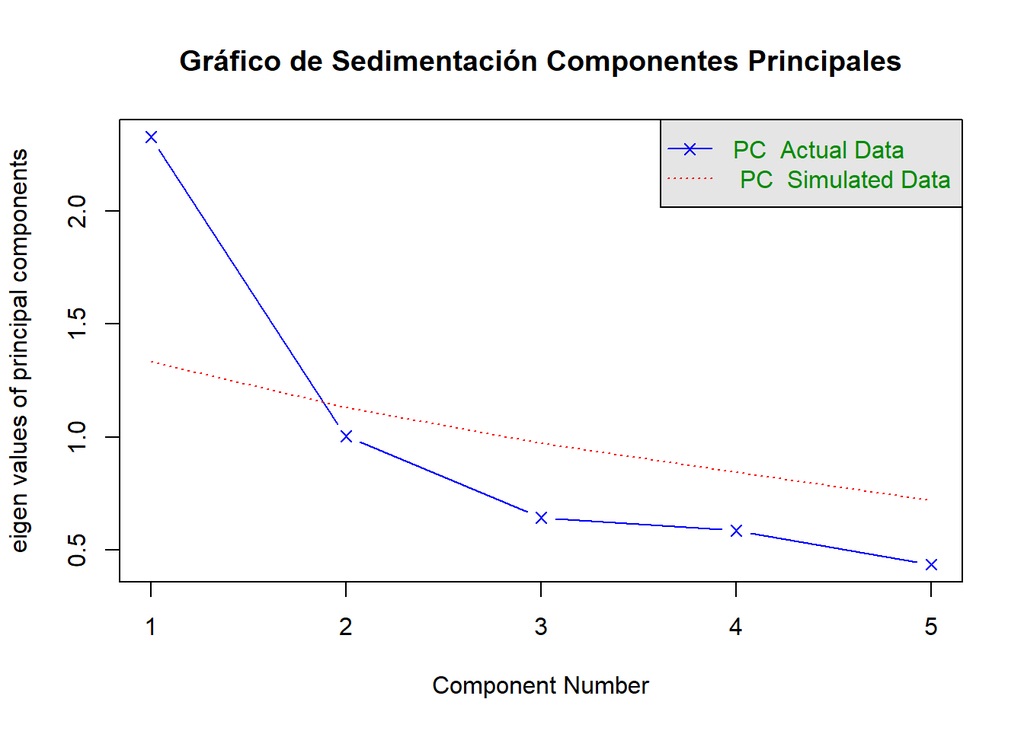

```
## Parallel analysis suggests that the number of factors =  NA  and the number of components =  1
```

```r
fa.parallel(corMatrix2,fm="pa",fa="pc",main="Gráfico de Sedimentación Componentes Principales")
```

```r
#Eigen values:
res.pca2=PCA(subset_uruguay_ind, graph = FALSE)
eig.val2=get_eig(res.pca2)
eig.val2
```

```
##       eigenvalue variance.percent cumulative.variance.percent
## Dim.1  2.2439718        44.879436                    44.87944
## Dim.2  1.0492069        20.984139                    65.86357
## Dim.3  0.6574540        13.149080                    79.01265
## Dim.4  0.6090079        12.180158                    91.19281
## Dim.5  0.4403594         8.807188                   100.00000
```

Dado que en el análisis de autovalores nos indica que hay 2 componentes que son mayores a 1, vamos a interpretarlo como que hay 2 componentes principales entre las variables independientes en el caso de Uruguay.

Ahora le otorgamos un nombre adecuado a estos 2 componentes: Para otorgar un nombre apropiado a los componentes identificados, primero realizaremos una rotación para ajustar los componentes para que sean más estables.

```r
comp2=pca(subset_uruguay_ind,nfactors=2,rotate = "varimax")
print(comp2$loadings)
```

```
##
## Loadings:
##                     RC1    RC2
## p2st                 0.795
## P11STGBS.B           0.724 -0.162
## p17stgbs             0.744 -0.202
## indice_conf_pais    -0.468  0.704
## indice_conf_inst_ng         0.918
##
##                  RC1   RC2
## SS loadings    1.929 1.407
## Proportion Var 0.386 0.281
## Cumulative Var 0.386 0.667
```

En una primera instancia, observamos que todas las variables están en el Componente 1, a excepción de la variable “Confianza en las Instituciones No gubernamentales”. De manera análoga, en el Componente 2 no se encuentra la variable “Imagen del progreso del país”. Por un lado, en el Componente 1 las variables “Imagen del progreso del país”, “Satisfacción con el funcionamiento de la economía” y “Aprobación de la gestión del gobierno del presidente” son las que más lo explican.Por otro lado, las variables “Confianza en las instituciones no gubernamentales” y “Confianza en las instituciones del país” son las que más explican el Componente 2. De esta manera, mientras que el Componente 1 se llamará “Percepción del país”, el Componente 2 se llamará “Confianza en las instituciones”. Finalmente, es preciso destacar que el Cumulative Var indica que los 2 Componentes ayudan a explicar aproximadamente el 66,7% de las variables independientes.

Esto se observará de manera gráfica:

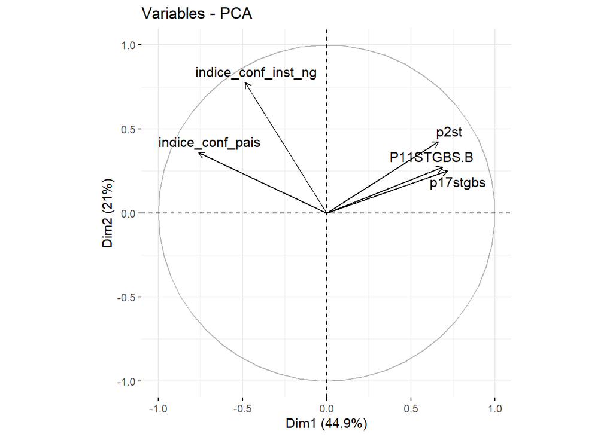

```r
fviz_pca_var(res.pca2, col.var = "black",repel = TRUE)
```

Ciertamente las variables del Componente 1 tienen ángulos más cercanos mientras que en el Componente 2 son las variables relacionadas a la confianza en las instituciones las que tienen ángulos más cercanos.

Ahora es preciso evaluar las comunalidades, complejidades y singularidades del análisis factorial realizado.

```r
#Comunalidades
sort(comp2$communality)
```

```
##          P11STGBS.B            p17stgbs                p2st    indice_conf_pais
##           0.5510700           0.5941663           0.6323128           0.7149555
## indice_conf_inst_ng
##           0.8436175
```

Ordenamos la varianza común: - En primer lugar, parece ser que la variable “Índice de confianza en las instituciones no gubernamentales” es la que más aporta en los componentes, con una comunalidad de 0.84.

Luego, la variable “Índice de confianza en las instituciones del país” es la segunda que más aporta en los componentes, con una comunalidad de 0.71.

Después, la variable “Imagen del progreso del país” es la tercera, con una comunalidad de 0.63.

Luego, les sigue la variable “Aprobación de la gestión del gobierno del presidente”, con una comunalidad de 0.59.

Finalmente, la variable con menos comunalidad es la de la satisfacción con el funcionamiento de la economía en Uruguay, con una comunalidad de 0.55.

```r
#Complejidades
sort(comp2$complexity)
```

```
##                p2st indice_conf_inst_ng          P11STGBS.B            p17stgbs
##            1.000024            1.000676            1.100343            1.146981
##    indice_conf_pais
##            1.738749
```

Observamos que la variable “Índice de confainza en las instituciones del país” es la que más aporta en más de un componente, con una complejidad de 1.74. Por otro lado, la variable que menos aporta es la de “Imagen del progreso del país”.

```r
#Singularidades:
sort(comp2$uniquenesses)
```

```
## indice_conf_inst_ng    indice_conf_pais                p2st            p17stgbs
##           0.1563825           0.2850445           0.3676872           0.4058337
##          P11STGBS.B
##           0.4489300
```

Ciertamente, los índices sobre confianza en las instituciones son las que tienen menos singularidades. En cambio, la variable “satisfacción con el funcionamiento de la economía” es la que tiene más singularidades.

Ahora normalizamos las escalas:

```r
comp_2_casos=as.data.frame(comp2$scores)
head(comp_2_casos)
```

```
##               RC1        RC2
## 17805 -1.31760931  0.1050662
## 17806 -2.01668955 -0.7411701
## 17807  0.70335377 -0.5354291
## 17808          NA         NA
## 17809 -0.14953458  0.9526239
## 17810 -0.02727268  0.9140224
```

```r
summary(comp_2_casos)
```

```
##       RC1                RC2
##  Min.   :-2.34984   Min.   :-4.29217
##  1st Qu.:-0.74980   1st Qu.:-0.40549
##  Median : 0.10315   Median : 0.13498
##  Mean   : 0.01347   Mean   : 0.07462
##  3rd Qu.: 0.83018   3rd Qu.: 0.61855
##  Max.   : 2.18512   Max.   : 2.32923
##  NA's   :157        NA's   :157
```

```r
subset_uruguay_ind$comp_1=comp_2_casos$RC1
subset_uruguay_ind$comp_2=comp_2_casos$RC2
```

```r
#Estandarizamos el Componente 1 (Percepción del país):
subset_uruguay_ind$comp_1_normalizado=normalize(subset_uruguay_ind$comp_1,
                                        method = "range",
                                        margin=2, # by column
                                        range = c(0, 100))
summary(subset_uruguay_ind$comp_1_normalizado)
```

```
##    Min. 1st Qu.  Median    Mean 3rd Qu.    Max.    NA's
##    0.00   35.28   54.09   52.11   70.12  100.00     157
```

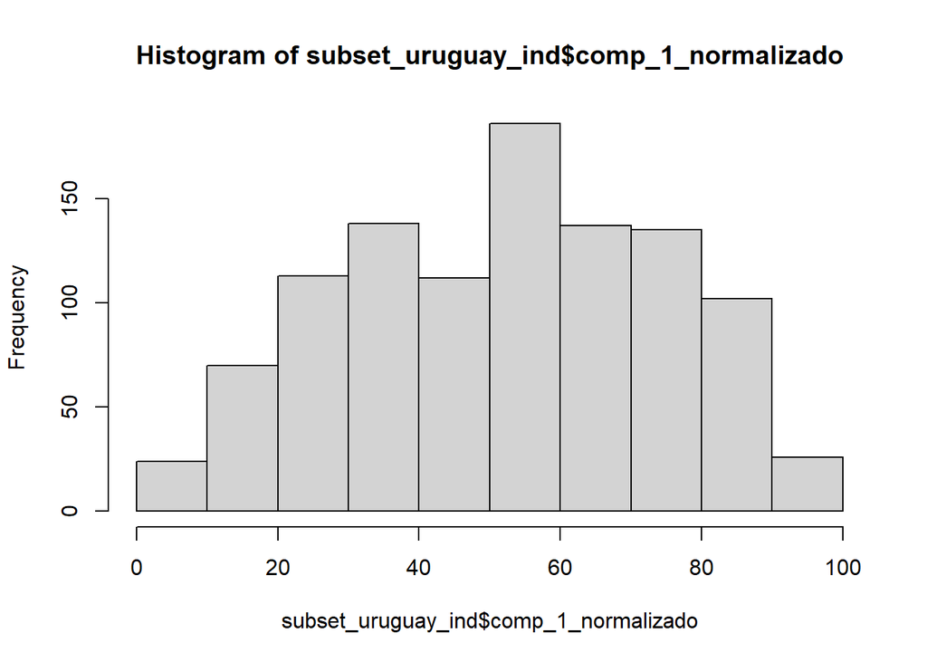

```r
hist(subset_uruguay_ind$comp_1_normalizado)
```

```r
#Estandarizamos el Componente 2 (Confianza en las instituciones):
subset_uruguay_ind$comp_2_normalizado=normalize(subset_uruguay_ind$comp_2,
                                        method = "range",
                                        margin=2, # by column
                                        range = c(0, 100))
summary(subset_uruguay_ind$comp_2_normalizado)
```

```
##    Min. 1st Qu.  Median    Mean 3rd Qu.    Max.    NA's
##    0.00   58.70   66.86   65.95   74.16  100.00     157
```

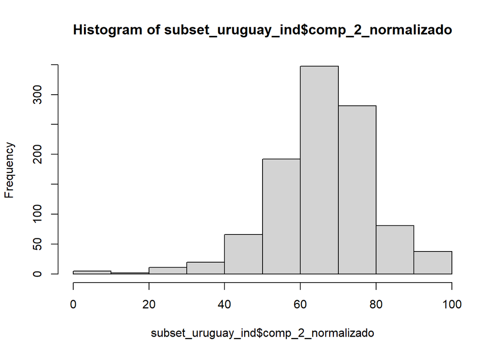

```r
hist(subset_uruguay_ind$comp_2_normalizado)
```

Al igual que en el caso venezolano, antes de elaborar los modelos primero es preciso recodificar las variables dependientes para que vayan según la misma lógica que las variables independientes:

Satisfacción con la democracia:

```r
str(subset_venezuela$P11STGBS.A)
```

```
##  num [1:1200] 4 2 4 1 2 1 1 3 1 1 ...
```

```r
subset_uruguay_ind$satisfaccion_democracia=subset_uruguay$P11STGBS.A
subset_uruguay_ind$satisfaccion_democracia[subset_uruguay_ind$satisfaccion_democracia=="-1"]=NA
subset_uruguay_ind$satisfaccion_democracia[subset_uruguay_ind$satisfaccion_democracia=="-2"]=NA
table(subset_uruguay_ind$satisfaccion_democracia)
```

```
##
##   1   2   3   4
## 278 542 257  83
```

```r
subset_uruguay_ind$satisfaccion_democracia=recode(subset_uruguay_ind$satisfaccion_democracia,"1=4;2=3;3=2;4=1")
table(subset_uruguay_ind$satisfaccion_democracia)
```

```
##
##   1   2   3   4
##  83 257 542 278
```

Apoyo a la democracia:

```r
subset_uruguay_ind$apoyo_democracia=subset_uruguay$p10stgbs
str(subset_uruguay_ind$apoyo_democracia)
```

```
##  int [1:1200] 1 1 2 3 2 1 2 1 1 1 ...
```

```r
subset_uruguay_ind$apoyo_democracia=as.numeric(subset_uruguay_ind$apoyo_democracia)
subset_uruguay_ind$apoyo_democracia[subset_uruguay_ind$apoyo_democracia=="-1"]=NA
subset_uruguay_ind$apoyo_democracia[subset_uruguay_ind$apoyo_democracia=="-2"]=NA
table(subset_uruguay_ind$apoyo_democracia)
```

```
##
##   1   2   3
## 888  93 150
```

```r
subset_uruguay_ind$apoyo_democracia=recode(subset_uruguay_ind$apoyo_democracia,"1=3;2=1;3=2")
table(subset_uruguay_ind$apoyo_democracia)
```

```
##
##   1   2   3
##  93 150 888
```

#Ahora elaboramos el modelo de regresión múltiple con la variable “Satisfacción con la democracia” como dependiente y los componentes identificados como dependientes, en el caso uruguayo:

```r
modelo_uruguay=lm(subset_uruguay_ind$satisfaccion_democracia~subset_uruguay_ind$comp_1_normalizado+subset_uruguay_ind$comp_2_normalizado)
summary(modelo_uruguay)
```

```
##
## Call:
## lm(formula = subset_uruguay_ind$satisfaccion_democracia ~ subset_uruguay_ind$comp_1_normalizado +
##     subset_uruguay_ind$comp_2_normalizado)
##
## Residuals:
##      Min       1Q   Median       3Q      Max
## -2.23540 -0.43725 -0.03421  0.58752  1.82781
##
## Coefficients:
##                                        Estimate Std. Error t value Pr(>|t|)
## (Intercept)                            2.814242   0.132691  21.209  < 2e-16 ***
## subset_uruguay_ind$comp_1_normalizado  0.015709   0.001079  14.559  < 2e-16 ***
## subset_uruguay_ind$comp_2_normalizado -0.011380   0.001782  -6.385 2.59e-10 ***
## ---
## Signif. codes:  0 '***' 0.001 '**' 0.01 '*' 0.05 '.' 0.1 ' ' 1
##
## Residual standard error: 0.7732 on 1022 degrees of freedom
##   (175 observations deleted due to missingness)
## Multiple R-squared:  0.1989, Adjusted R-squared:  0.1973
## F-statistic: 126.9 on 2 and 1022 DF,  p-value: < 2.2e-16
```

Recordamos:

Componente 1= Componente Percepción del país.

Componente 2= Confianza en las instituciones.

En primer lugar, es preciso mencionar que, dado el p-value 2.2e-16, el cual es menor a 0.05, podemos afirmar que el modelo es válido. Luego, dado el Adjusted r-squared de 0.1973, podemos afirmar que la satisfacción de la democracia en Uruguay es explicada en un 19.73% por la percepción que tienen los ciudadanos de su país, y la confianza en las instituciones dentro del mismo. De manera análoga, ambos componentes tienen p-values menores a 0.05, por lo que ambos son significativos y aportan al modelo.

No obstante, es preciso destacar que, mientras que la confianza en las instituciones tiene una relación inversa con la satisfacción con la democracia de una persona en Uruguay, su percepción del país, tanto mediante la aprobación del gobierno del presidente como la satisfacción con el funcionamiento de la economía tiene una relación directa con la variable dependiente.

```r
#Coeficientes:
modelo_uruguay$coefficients
```

```
##                           (Intercept) subset_uruguay_ind$comp_1_normalizado
##                            2.81424173                            0.01570867
## subset_uruguay_ind$comp_2_normalizado
##                           -0.01138005
```

A partir de los coeficientes, planteamos la siguiente ecuación: Satisfacción con la democracia= 2.81424173 + 0.01570867(Percepción sobre el país) -0.01138005(Confianza en las instituciones)

#Ahora elaboramos el modelo con la variable “Apoyo a la democracia”.

```r
modelo_2_uruguay=lm(subset_uruguay_ind$apoyo_democracia~subset_uruguay_ind$comp_1_normalizado+subset_uruguay_ind$comp_2_normalizado)
summary(modelo_2_uruguay)
```

```
##
## Call:
## lm(formula = subset_uruguay_ind$apoyo_democracia ~ subset_uruguay_ind$comp_1_normalizado +
##     subset_uruguay_ind$comp_2_normalizado)
##
## Residuals:
##     Min      1Q  Median      3Q     Max
## -1.8232  0.2447  0.2882  0.3204  0.4073
##
## Coefficients:
##                                         Estimate Std. Error t value Pr(>|t|)
## (Intercept)                            2.7967266  0.1111991  25.151   <2e-16
## subset_uruguay_ind$comp_1_normalizado  0.0009965  0.0008813   1.131    0.258
## subset_uruguay_ind$comp_2_normalizado -0.0023279  0.0014975  -1.555    0.120
##
## (Intercept)                           ***
## subset_uruguay_ind$comp_1_normalizado
## subset_uruguay_ind$comp_2_normalizado
## ---
## Signif. codes:  0 '***' 0.001 '**' 0.01 '*' 0.05 '.' 0.1 ' ' 1
##
## Residual standard error: 0.62 on 992 degrees of freedom
##   (205 observations deleted due to missingness)
## Multiple R-squared:  0.003727,   Adjusted R-squared:  0.001719
## F-statistic: 1.856 on 2 and 992 DF,  p-value: 0.1569
```

En el caso del presente modelo, parece ser que no sería válido ni sus variables significativas, dados sus p-values mayores a 0.05. Sin embargo, es preciso mencionar que en el presente modelo el componente “Percepción sobre el país”tiene una relación directa con el apoyo a la democracia de una persona. En cambio, la confianza en las instituciones parece tener una relación inversa con su apoyo a la democracia. Ciertamente, parece ser que el apoyo a la democracia de una persona estaría influenciado por diversos factores, no solamente los presentes entre las variables seleccionadas.

```r
#Coeficientes:
modelo_2_uruguay$coefficients
```

```
##                           (Intercept) subset_uruguay_ind$comp_1_normalizado
##                          2.7967265689                          0.0009964774
## subset_uruguay_ind$comp_2_normalizado
##                         -0.0023279064
```

#Hallazgos: En primer lugar, con relación al caso de Venezuela, se halló que ciertamente, hay una insatisfacción con la democracia pero que, de igual manera, se sigue prefiriendo a la democracia como régimen democrático como parte de la variable dependiente “Apoyo a la democracia”. En este sentido, se responde a la hipótesis planteada de que la satisfacacción con la democracia en Venezuela, desde la llegada de Hugo Chávez, ha ido en deterioro. En este sentido, es importante destacar lo hallado como parte del análisis de componentes. En el caso venezolano se encontró que las variables “Índice de Confianza en las instituciones del país”, “Índice de confianza en las instituciones no gubernamentales”, “aprobación del gobierno del presidente Maduro”, “Satisfacción con el funcionamiento de la economía” y “imagen del progreso del país”, entran dentro del mismo componente. Este componente tiene una relación directa con la democracia en el sentido de que se evidencia, no solo en el modelo propuesto, sino que también en el hecho de que en la parte descriptiva se encontró que, ciertamente, había poca aprobación al gobierno de Maduro que ciertamente se tradujo en una menor satisfacción con la democracia, entre otras variables. De esta manera, se confirma la hipótesis planteada sobre el caso venezolano, sobre la línea de cumplilr el objetivo de explicar la variabilidad en la satisfacción de la democracia en este país. Por otro lado, en el caso de Uruguay, se encontró que la satisfacción de la democracia es medianamente alta, en corcondancia con una buena gestión del presidente Lacalle, especialmente en el contexto de la pandemia. Ciertamente, se econtró que los ciudadanos uruguayos siguen estando satisfechos con la democracia y la siguen prefiriendo como sistema de gobierno, confirmando la hipótesis planteada. Asímismo es preciso destacar que, con relación a las variables independientes, el análisis de componentes indicó que, en el caso uruguayo, estas están divididas en 2: Componente “Percepción sobre el país” y Componente “Confianza en las instituciones”. De esta manera, en el primer modelo sobre Uruguay propuesto, utilizando la variable “satisfacción con la democracia” como dependiente y los 2 componentes como variables independientes, se encontró que la percepción sobre el país (componente 1) juega un papel importante en la satisfacción con la democracia de una persona, al tener una relación directa con esta variable. Por otro lado, la confianza en las instituciones juega un rol importante, mas de manera inversa con relación a la satisfacción con la democracia. En este sentido, las políticas públicas elaboradas por el presidente Lacalle y su buena gestión durante la pandemia probablemente han impactado positivamente en la percepción de las personas sobre el país en general. Por otro lado, en los últimos años se han observado diversas movilizaciones en todo América Latina que ciertamente han criticado las instituciones tradicionales, exigiendo menores actos de corrupción, mayores libertades, agendas más humanistas y demás, temas que la democracia ciertamente engloba. Lo mismo sucedió con el apoyo a la democracia en Uruguay, donde la percepción sobre el país tenía una relación directa pero la confianza en las instituciones una relación inversa. Por lo tanto, se podría afirmar que, a menor confianza en las instituciones, una persona preferiría una democracia como forma de gobierno, para precisamente fortalezerlas, tal como sucedió antes de la llegada de Lacalle a la presidencia y su gestió eficaz al fortalecerlas, tal como se planteó en la hipótesis. Asimismo, es preciso destacar que, en el caso del apoyo a la democracia, esta variable presentó una limitación al momento de elaborar modelos, tanto en el caso de Venezuela como en el caso de Uruguay. Ciertamente, se encontró que los modelos elaborados con esta variable no fueron significativos ni válidos, probablemente por las singularidades que cada persona tiene en su preferencia por un régimen democrático, entre otros factores que ciertamente influyen en este apoyo. Sin embargo, de igual manera era importante mencionar la relación entre los componentes y esta variable.

El link del repositorio con la base de datos, el rmd, el html y el libro de códigos de la base de datos es el siguiente:

https://github.com/EmilianoZepeda/Avance-2-Zepeda-e-Iberico-Trabajo-Grupal.git